# Lab 5

Author

Diya Patel

GitHub Link: https://github.com/diyapatel040124/GSB-544-Computing-and-Machine-Learning/blob/main/Lab_5.html

Part One: Data Exploration 1. Read in the dataset, and display some summaries of the data

```python
import pandas as pd
import numpy as np
df = pd.read_csv("insurance_costs_1.csv")
print(df)
df.info()
df.describe()
```

```
     age     sex     bmi smoker     region      charges
0     19  female  27.900    yes  southwest  16884.92400
1     33    male  22.705     no  northwest  21984.47061
2     32    male  28.880     no  northwest   3866.85520
3     31  female  25.740     no  southeast   3756.62160
4     60  female  25.840     no  northwest  28923.13692
..   ...     ...     ...    ...        ...          ...
426   23  female  33.400     no  southwest  10795.93733
427   18  female  31.920     no  northeast   2205.98080
428   18  female  36.850     no  southeast   1629.83350
429   21  female  25.800     no  southwest   2007.94500
430   61  female  29.070    yes  northwest  29141.36030

[431 rows x 6 columns]
<class 'pandas.core.frame.DataFrame'>
RangeIndex: 431 entries, 0 to 430
Data columns (total 6 columns):
 #   Column   Non-Null Count  Dtype
---  ------   --------------  -----
 0   age      431 non-null    int64
 1   sex      431 non-null    object
 2   bmi      431 non-null    float64
 3   smoker   431 non-null    object
 4   region   431 non-null    object
 5   charges  431 non-null    float64
dtypes: float64(2), int64(1), object(3)
memory usage: 20.3+ KB
```

|  | age | bmi | charges |
| --- | --- | --- | --- |
| count | 431.000000 | 431.000000 | 431.000000 |
| mean | 37.960557 | 30.768898 | 12297.098118 |
| std | 16.363909 | 6.111362 | 11876.527128 |
| min | 18.000000 | 15.960000 | 1131.506600 |
| 25% | 22.000000 | 26.357500 | 2710.444575 |
| 50% | 34.000000 | 30.590000 | 9866.304850 |
| 75% | 55.000000 | 35.272500 | 14510.872600 |
| max | 64.000000 | 49.060000 | 55135.402090 |

2. Fix any concerns you have about the data.

```python
df.dropna()

sex_dummy = pd.get_dummies(df['sex'])
smoker_dummy = pd.get_dummies(df['smoker'], prefix='smoker')
region_dummy = pd.get_dummies(df['region'])

df = pd.concat([df, sex_dummy, smoker_dummy, region_dummy], axis=1)
df
```

|  | age | sex | bmi | smoker | region | charges | female | male | smoker_no | smoker_yes | northeast | northwest | southeast | southwest |
| --- | --- | --- | --- | --- | --- | --- | --- | --- | --- | --- | --- | --- | --- | --- |
| 0 | 19 | female | 27.900 | yes | southwest | 16884.92400 | True | False | False | True | False | False | False | True |
| 1 | 33 | male | 22.705 | no | northwest | 21984.47061 | False | True | True | False | False | True | False | False |
| 2 | 32 | male | 28.880 | no | northwest | 3866.85520 | False | True | True | False | False | True | False | False |
| 3 | 31 | female | 25.740 | no | southeast | 3756.62160 | True | False | True | False | False | False | True | False |
| 4 | 60 | female | 25.840 | no | northwest | 28923.13692 | True | False | True | False | False | True | False | False |
| ... | ... | ... | ... | ... | ... | ... | ... | ... | ... | ... | ... | ... | ... | ... |
| 426 | 23 | female | 33.400 | no | southwest | 10795.93733 | True | False | True | False | False | False | False | True |
| 427 | 18 | female | 31.920 | no | northeast | 2205.98080 | True | False | True | False | True | False | False | False |
| 428 | 18 | female | 36.850 | no | southeast | 1629.83350 | True | False | True | False | False | False | True | False |
| 429 | 21 | female | 25.800 | no | southwest | 2007.94500 | True | False | True | False | False | False | False | True |
| 430 | 61 | female | 29.070 | yes | northwest | 29141.36030 | True | False | False | True | False | True | False | False |

431 rows × 14 columns

3. Make up to three plots comparing the response variable (charges) to one of the predictor variables. Briefly discuss each plot.

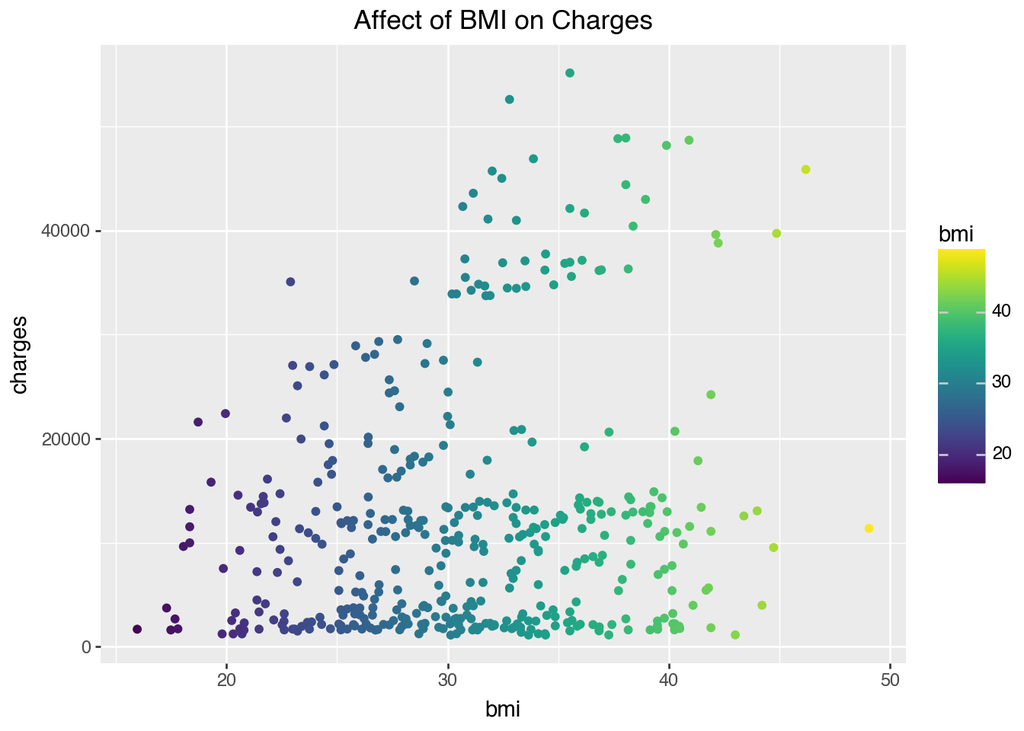

```python
import plotnine
from plotnine import *
(
    ggplot(df, aes(x='bmi', y='charges', color='bmi'))
    + geom_point()
    + labs
        (title='Affect of BMI on Charges')
)
```

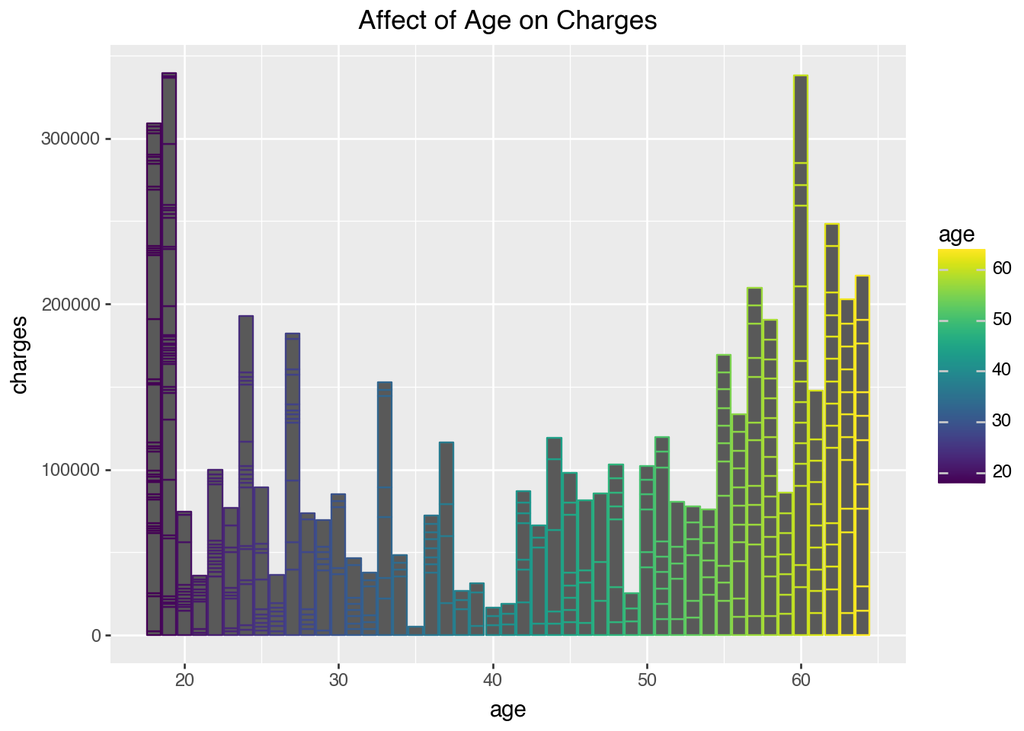

```python
(
    ggplot(df, aes(x='age', y='charges', color='age'))
    + geom_col()
    + labs(title='Affect of Age on Charges')
)
```

At age 20 and 60, charges are the highest.

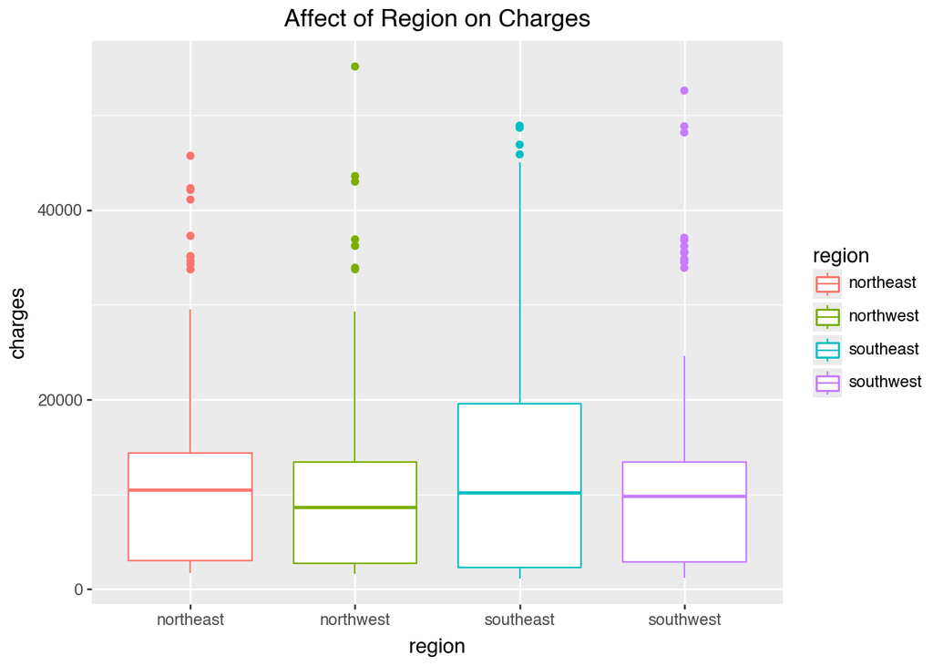

```python
(
    ggplot(df, aes(x='region', y='charges', color='region'))
    + geom_boxplot()
    + labs(title='Affect of Region on Charges')
)
```

The region with the highest charges is the southeast.

Part Two: Simple Linear Models 1. Construct a simple linear model to predict the insurance changes from the beneficiary’s age. Discuss the model fit, and interpret the coefficient estimates.

```python
from sklearn.linear_model import LinearRegression

# linear model
charge_model = LinearRegression()
charge_model.fit(
    X=df[["age"]],
    y=df["charges"]
)
```

```
LinearRegression()
```

```python
charge_model.coef_, charge_model.intercept_
```

```
(array([228.79904937]), np.float64(3611.758798507093))
```

The intercept of 3611.76 is the predicted insurance charge when age=0 The coefficient of 228.8 means that every one-year increase in age, the model predicts an increase of $228.80 in insurance changes, on average, holding everything else constant.

2. Make a model that also incorporates the variable sex. Report your results

```python
charge_model = LinearRegression()
charge_model.fit(
    X=df[["age", "female", "male"]],
    y=df["charges"])
```

```
LinearRegression()
```

```python
charge_model.coef_, charge_model.intercept_
```

```
(array([ 228.42586236, -324.91629499,  324.91629499]),
 np.float64(3640.2486415205185))
```

The intercept of 3640.28 is the predicted insurance charge when all predictors are 0, when age=0, and when female=0, male=0. The age coefficient 228.45 means that for every 1 year of age, charges increase by $228.45, on average, holding sex constant. The female coefficient -324.92 means that charges decrease by $324.92 for females The male coefficient 324.92 means that charges increase by about $324.92 for males.

3. Now make a model that does not include sex, but does include smoker. Report your results.

```python
charge_model = LinearRegression()
charge_model.fit(
    X=df[["age", "smoker_no", "smoker_yes"]],
    y=df["charges"])
```

```
LinearRegression()
```

```python
charge_model.coef_, charge_model.intercept_
```

```
(array([   253.14535549, -12024.43371898,  12024.43371898]),
 np.float64(9857.5814236015))
```

The intercept of 9857.58 is the predicted insurance charge when age, nonsmokers, and smokers = 0 The age coefficient of 253.15 means that for every every of year-year increase in age, the model predicts an average increase of $253.15 in insurance charges. Smoker_no means that the model predicts a decrease of about $12,024 in insurance charges Smoker_yes means that the model predicts an increase of about $12,024 in insurance charges

4. Which model (Q2 or Q3) do you think better fits the data? Justify your answer by calculating the MSE for each model, and also by comparing R-squared values.

```python
from sklearn.metrics import mean_squared_error, r2_score
# MSE / R^2 for Q2
X_train = df[["age", "female", "male"]]
y_train = df["charges"]
charge_model = LinearRegression()
charge_model.fit(
    X=X_train,
    y=y_train
)

# Calculate the model predictions on the training data
y_train_ = charge_model.predict(X=X_train)

# Calculate the mean-squared error
mean_squared_error(y_train, y_train_)
```

```
126633939.67937087
```

Q2 MSE = 126633939.67937087 R^2 = 0.10012952499706396

```python
r2_score(y_train, y_train_)
```

```
0.10012952499706396
```

```python
from sklearn.metrics import mean_squared_error, r2_score
# MSE / R^2 for Q3
X_train = df[["age", "smoker_no", "smoker_yes"]]
y_train = df["charges"]
charge_model = LinearRegression()
charge_model.fit(
    X=X_train,
    y=y_train
)

# Calculate the model predictions on the training data
y_train_ = charge_model.predict(X=X_train)

# Calculate the mean-squared error
mean_squared_error(y_train, y_train_)
```

```
33719831.46524372
```

Q3 MSE = 33719831.46524372 R^2 = 0.7603842948069405

Q3 better fits the model with an R^2 value that is closer to one. It is also best to use whether a person a smoker or not as predictors because that is what the model best predicts.

```python
r2_score(y_train, y_train_)
```

```
0.7603842948069405
```

Part Three: Multiple Linear Models 1. Fit a model that uses age and bmi as predictors. (Do not include an interaction term, age*bmi, between these two.) Report your results. How does the MSE compare to the model in Part Two Q1? How does the R-Squared compare?

```python
charge_model = LinearRegression()
charge_model.fit(
    X=df[["age", "bmi"]],
    y=df["charges"])
```

```
LinearRegression()
```

```python
charge_model.coef_, charge_model.intercept_
```

```
(array([216.29721472, 283.20380126]), np.float64(-4627.533445708497))
```

The intercept of -4627.53 is the predicted insurance charge when both age and bmi = 0. Holding BMI constant, for every one-year increase in age, the model predicts an average increase of $216.30 in insurance charges. The older a person gets, the more they tend to have higher insurance costs, even if their BMI stays the same. Holding age constant, for every one-unit increase in BMI, the model predicts an average increase of $283.20 in insurance charges. The higher the BMI, the higher the insurance charges will be.

```python
# MSE / R^2 for Part 2: Q1
X_train = df[["age"]]
y_train = df["charges"]
charge_model = LinearRegression()
charge_model.fit(
    X=X_train,
    y=y_train
)

# Calculate the model predictions on the training data
y_train_ = charge_model.predict(X=X_train)

# Calculate the mean-squared error
mean_squared_error(y_train, y_train_)
```

```
126739267.9102639
```

Q1 MSE = 126739267.9102639 R^2 = 0.09938105452062695

```python
r2_score(y_train, y_train_)
```

```
0.09938105452062695
```

```python
# MSE / R^2 for Part Three: Q1
X_train = df[["age", "bmi"]]
y_train = df["charges"]
charge_model = LinearRegression()
charge_model.fit(
    X=X_train,
    y=y_train
)

# Calculate the model predictions on the training data
y_train_ = charge_model.predict(X=X_train)

# Calculate the mean-squared error
mean_squared_error(y_train, y_train_)
```

```
123792439.58129103
```

P3 Q1 MSE = 123792439.58129103 R^2 = 0.12032144234129338

```python
r2_score(y_train, y_train_)
```

```
0.12032144234129338
```

2. Perhaps the relationships are not linear. Fit a model that uses age and age^2 as predictors. How do the MSE and R-squared compare to the model in P2 Q1?

```python
df["age_square"] = df["age"] ** 2
df
```

|  | age | sex | bmi | smoker | region | charges | female | male | smoker_no | smoker_yes | northeast | northwest | southeast | southwest | age_square |
| --- | --- | --- | --- | --- | --- | --- | --- | --- | --- | --- | --- | --- | --- | --- | --- |
| 0 | 19 | female | 27.900 | yes | southwest | 16884.92400 | True | False | False | True | False | False | False | True | 361 |
| 1 | 33 | male | 22.705 | no | northwest | 21984.47061 | False | True | True | False | False | True | False | False | 1089 |
| 2 | 32 | male | 28.880 | no | northwest | 3866.85520 | False | True | True | False | False | True | False | False | 1024 |
| 3 | 31 | female | 25.740 | no | southeast | 3756.62160 | True | False | True | False | False | False | True | False | 961 |
| 4 | 60 | female | 25.840 | no | northwest | 28923.13692 | True | False | True | False | False | True | False | False | 3600 |
| ... | ... | ... | ... | ... | ... | ... | ... | ... | ... | ... | ... | ... | ... | ... | ... |
| 426 | 23 | female | 33.400 | no | southwest | 10795.93733 | True | False | True | False | False | False | False | True | 529 |
| 427 | 18 | female | 31.920 | no | northeast | 2205.98080 | True | False | True | False | True | False | False | False | 324 |
| 428 | 18 | female | 36.850 | no | southeast | 1629.83350 | True | False | True | False | False | False | True | False | 324 |
| 429 | 21 | female | 25.800 | no | southwest | 2007.94500 | True | False | True | False | False | False | False | True | 441 |
| 430 | 61 | female | 29.070 | yes | northwest | 29141.36030 | True | False | False | True | False | True | False | False | 3721 |

431 rows × 15 columns

```python
square_model = LinearRegression()
square_model.fit(
    X=df[["age", "age_square"]],
    y=df["charges"]
)
```

```
LinearRegression()
```

```python
square_model.coef_, square_model.intercept_
```

```
(array([308.42816984,  -1.00150889]), np.float64(2299.730568726638))
```

The intercept of 2299.73 is the predicted insurance charges when both age and age^2 is 0. The age coefficient of 308.43 is the linear effect of age: as age increases, charges initially rise by $308.43 per year and Age^2 coefficient -1.00, is the curvature term. Since it is negative, it means that as poeple get older, the rate of increase in charges slows down. Insurance charges increase with age, but the growth rate gets smaller at older ages.

```python
# MSE / R^2 for Part Three: Q2
X_train = df[["age", "age_square"]]
y_train = df["charges"]
square_model = LinearRegression()
square_model.fit(
    X=X_train,
    y=y_train
)

# Calculate the model predictions on the training data
y_train_ = square_model.predict(X=X_train)

# Calculate the mean-squared error
mean_squared_error(y_train, y_train_)
```

```
126710293.80956802
```

P3 Q2 MSE = 126710293.80956802 R^2 = 0.09958694669946933

```python
r2_score(y_train, y_train_)
```

```
0.09958694669946933
```

3. Fit a polynomial model of degree 4. How do the MSE and R-squared compare to the model in P2 Q1?

```python
df["age_square"] = df["age"] ** 2
df["age_3"] = df["age"] ** 3
df["age_4"] = df["age"] ** 4
df
```

|  | age | sex | bmi | smoker | region | charges | female | male | smoker_no | smoker_yes | northeast | northwest | southeast | southwest | age_square | age_3 | age_4 |
| --- | --- | --- | --- | --- | --- | --- | --- | --- | --- | --- | --- | --- | --- | --- | --- | --- | --- |
| 0 | 19 | female | 27.900 | yes | southwest | 16884.92400 | True | False | False | True | False | False | False | True | 361 | 6859 | 130321 |
| 1 | 33 | male | 22.705 | no | northwest | 21984.47061 | False | True | True | False | False | True | False | False | 1089 | 35937 | 1185921 |
| 2 | 32 | male | 28.880 | no | northwest | 3866.85520 | False | True | True | False | False | True | False | False | 1024 | 32768 | 1048576 |
| 3 | 31 | female | 25.740 | no | southeast | 3756.62160 | True | False | True | False | False | False | True | False | 961 | 29791 | 923521 |
| 4 | 60 | female | 25.840 | no | northwest | 28923.13692 | True | False | True | False | False | True | False | False | 3600 | 216000 | 12960000 |
| ... | ... | ... | ... | ... | ... | ... | ... | ... | ... | ... | ... | ... | ... | ... | ... | ... | ... |
| 426 | 23 | female | 33.400 | no | southwest | 10795.93733 | True | False | True | False | False | False | False | True | 529 | 12167 | 279841 |
| 427 | 18 | female | 31.920 | no | northeast | 2205.98080 | True | False | True | False | True | False | False | False | 324 | 5832 | 104976 |
| 428 | 18 | female | 36.850 | no | southeast | 1629.83350 | True | False | True | False | False | False | True | False | 324 | 5832 | 104976 |
| 429 | 21 | female | 25.800 | no | southwest | 2007.94500 | True | False | True | False | False | False | False | True | 441 | 9261 | 194481 |
| 430 | 61 | female | 29.070 | yes | northwest | 29141.36030 | True | False | False | True | False | True | False | False | 3721 | 226981 | 13845841 |

431 rows × 17 columns

```python
degree_four = LinearRegression()
degree_four.fit(
    X=df[["age", "age_square", "age_3", "age_4"]],
    y=df["charges"]
)
```

```
LinearRegression()
```

```python
degree_four.coef_, degree_four.intercept_
```

```
(array([-7.94841022e+03,  3.58110163e+02, -6.47905090e+00,  4.12933982e-02]),
 np.float64(68637.89783236325))
```

```python
# MSE / R^2 for Part Three: Q3
X_train = df[["age", "age_square", "age_3" ,"age_4"]]
y_train = df["charges"]
degree_four = LinearRegression()
degree_four.fit(
    X=X_train,
    y=y_train
)

# Calculate the model predictions on the training data
y_train_ = degree_four.predict(X=X_train)

# Calculate the mean-squared error
mean_squared_error(y_train, y_train_)
```

```
125550389.64569828
```

P3 Q3 MSE = 125550389.64569828 R^2 = 0.10782931453183786

The R^2 is closer to 1, again suggesting this is an overall better model.

```python
r2_score(y_train, y_train_)
```

```
0.10782931453183786
```

4. Fit a polynomial model of degree 12. How do the MSE and R-squared compare to the model in P2 Q1?

```python
df["age_5"] = df["age"] ** 5
df["age_6"] = df["age"] ** 6
df["age_7"] = df["age"] ** 7
df["age_8"] = df["age"] ** 8
df["age_9"] = df["age"] ** 9
df["age_10"] = df["age"] ** 10
df["age_11"] = df["age"] ** 11
df["age_twelve"] = df["age"] ** 12
df
```

|  | age | sex | bmi | smoker | region | charges | female | male | smoker_no | smoker_yes | ... | age_3 | age_4 | age_5 | age_6 | age_7 | age_8 | age_9 | age_10 | age_11 | age_twelve |
| --- | --- | --- | --- | --- | --- | --- | --- | --- | --- | --- | --- | --- | --- | --- | --- | --- | --- | --- | --- | --- | --- |
| 0 | 19 | female | 27.900 | yes | southwest | 16884.92400 | True | False | False | True | ... | 6859 | 130321 | 2476099 | 47045881 | 893871739 | 16983563041 | 322687697779 | 6131066257801 | 116490258898219 | 2213314919066161 |
| 1 | 33 | male | 22.705 | no | northwest | 21984.47061 | False | True | True | False | ... | 35937 | 1185921 | 39135393 | 1291467969 | 42618442977 | 1406408618241 | 46411484401953 | 1531578985264449 | 50542106513726817 | 1667889514952984961 |
| 2 | 32 | male | 28.880 | no | northwest | 3866.85520 | False | True | True | False | ... | 32768 | 1048576 | 33554432 | 1073741824 | 34359738368 | 1099511627776 | 35184372088832 | 1125899906842624 | 36028797018963968 | 1152921504606846976 |
| 3 | 31 | female | 25.740 | no | southeast | 3756.62160 | True | False | True | False | ... | 29791 | 923521 | 28629151 | 887503681 | 27512614111 | 852891037441 | 26439622160671 | 819628286980801 | 25408476896404831 | 787662783788549761 |
| 4 | 60 | female | 25.840 | no | northwest | 28923.13692 | True | False | True | False | ... | 216000 | 12960000 | 777600000 | 46656000000 | 2799360000000 | 167961600000000 | 10077696000000000 | 604661760000000000 | -613782547419103232 | 66535302272909312 |
| ... | ... | ... | ... | ... | ... | ... | ... | ... | ... | ... | ... | ... | ... | ... | ... | ... | ... | ... | ... | ... | ... |
| 426 | 23 | female | 33.400 | no | southwest | 10795.93733 | True | False | True | False | ... | 12167 | 279841 | 6436343 | 148035889 | 3404825447 | 78310985281 | 1801152661463 | 41426511213649 | 952809757913927 | 21914624432020321 |
| 427 | 18 | female | 31.920 | no | northeast | 2205.98080 | True | False | True | False | ... | 5832 | 104976 | 1889568 | 34012224 | 612220032 | 11019960576 | 198359290368 | 3570467226624 | 64268410079232 | 1156831381426176 |
| 428 | 18 | female | 36.850 | no | southeast | 1629.83350 | True | False | True | False | ... | 5832 | 104976 | 1889568 | 34012224 | 612220032 | 11019960576 | 198359290368 | 3570467226624 | 64268410079232 | 1156831381426176 |
| 429 | 21 | female | 25.800 | no | southwest | 2007.94500 | True | False | True | False | ... | 9261 | 194481 | 4084101 | 85766121 | 1801088541 | 37822859361 | 794280046581 | 16679880978201 | 350277500542221 | 7355827511386641 |
| 430 | 61 | female | 29.070 | yes | northwest | 29141.36030 | True | False | False | True | ... | 226981 | 13845841 | 844596301 | 51520374361 | 3142742836021 | 191707312997281 | 11694146092834141 | 713342911662882601 | 6620429464016735429 | -1982172316589274383 |

431 rows × 25 columns

```python
degree_twelve = LinearRegression()
degree_twelve.fit(
    X=df[["age","age_square","age_3", "age_4", "age_5", "age_6", "age_7", "age_8", "age_9", "age_10", "age_11" ,"age_twelve"]],
    y=df["charges"]
)
```

```
LinearRegression()
```

```python
degree_twelve.coef_, degree_twelve.intercept_
```

```
(array([ 3.04916864e-12,  1.05406037e-10,  3.49790534e-09,  7.56584415e-08,
         1.26243848e-06,  1.25112288e-05, -2.08398111e-08, -1.85914310e-08,
         4.09818395e-10, -2.52044310e-12, -1.01992192e-17,  1.42766013e-16]),
 np.float64(7452.28232594397))
```

```python
# MSE / R^2 for Part Three: Q3
X_train = df[["age","age_square","age_3", "age_4", "age_5", "age_6", "age_7", "age_8", "age_9", "age_10", "age_11", "age_twelve"]]
y_train = df["charges"]
degree_twelve = LinearRegression()
degree_twelve.fit(
    X=X_train,
    y=y_train
)

# Calculate the model predictions on the training data
y_train_ = degree_twelve.predict(X=X_train)

# Calculate the mean-squared error
mean_squared_error(y_train, y_train_)
```

```
125373053.69365598
```

P3 Q4 MSE = 125373053.69365598 R^2 = 0.10908947739025832

Also higher R^2 value, suggesting this model is a better predictor than P2 Q1.

```python
r2_score(y_train, y_train_)
```

```
0.10908947739025832
```

5. According to the MSE and R-squared, which is the best model? Do you agree that this is indeed the “best” model? Why or why not?

According to the MSE and R-squared, for all of the multiple linears models ran in part three, the best model would be the model that uses age and bmi as predictors. I do not agree that this is the best overall predictor, because there is not much that can be explained with a high BMI, I believe the predicted insurance charges would best be predicted with the explanatory variable being whether the individual is a smoker or not. The model predicted in Part Two question 3, has the highest R^2 value which is closer to 1 and that I believe is the best model to predict insurance charges.

6. Plot the predictions from your model in Q4 as a line plot on top of the scatterplot of your original data.

[figure not shown]

```python
# plot syntax taken from Dr. Ross's colab notebook
X_new = pd.DataFrame()
X_new["age"] = np.linspace(0, 1, num=1000)

# recreate every polynomial feature
X_new["age_square"] = X_new["age"] ** 2
X_new["age_3"] = X_new["age"] ** 3
X_new["age_4"] = X_new["age"] ** 4
X_new["age_5"] = X_new["age"] ** 5
X_new["age_6"] = X_new["age"] ** 6
X_new["age_7"] = X_new["age"] ** 7
X_new["age_8"] = X_new["age"] ** 8
X_new["age_9"] = X_new["age"] ** 9
X_new["age_10"] = X_new["age"] ** 10
X_new["age_11"] = X_new["age"] ** 11
X_new["age_twelve"] = X_new["age"] ** 12

# plot
y_new = pd.Series(
    degree_twelve.predict(X_new),
    index=X_new["age"]
)
df.plot.scatter(x="age", y="charges")
y_new.plot.line(c = "pink")
```

Part Four: New data Consider the following possible models: - Only age as a predictor - age and bmi as a predictor - age, bmi, and smoker as predictors (no interaction terms) - age, and bmi, with both quantitative variables having an interaction term with smoker (the formula ~ (age + bmi): smoker) - age, bmi, and smoker as predictors, with both quantitative variables having an interaction term with smoker (the formula ~ (age + bmi)*smoker)

Only age as a predictor

```python
df_2 = pd.read_csv("insurance_costs_2.csv")

# Do the necessary cleaning
df_2.dropna()

sex_dummy = pd.get_dummies(df_2['sex'])
smoker_dummy = pd.get_dummies(df_2['smoker'], prefix='smoker')
region_dummy = pd.get_dummies(df_2['region'])

df_2 = pd.concat([df_2, sex_dummy, smoker_dummy, region_dummy], axis=1)
df_2
```

|  | age | sex | bmi | smoker | region | charges | female | male | smoker_no | smoker_yes | northeast | northwest | southeast | southwest |
| --- | --- | --- | --- | --- | --- | --- | --- | --- | --- | --- | --- | --- | --- | --- |
| 0 | 23 | male | 34.400 | no | southwest | 1826.84300 | False | True | True | False | False | False | False | True |
| 1 | 56 | male | 40.300 | no | southwest | 10602.38500 | False | True | True | False | False | False | False | True |
| 2 | 18 | male | 34.100 | no | southeast | 1137.01100 | False | True | True | False | False | False | True | False |
| 3 | 63 | female | 23.085 | no | northeast | 14451.83515 | True | False | True | False | True | False | False | False |
| 4 | 63 | male | 28.310 | no | northwest | 13770.09790 | False | True | True | False | False | True | False | False |
| ... | ... | ... | ... | ... | ... | ... | ... | ... | ... | ... | ... | ... | ... | ... |
| 138 | 19 | male | 34.900 | yes | southwest | 34828.65400 | False | True | False | True | False | False | False | True |
| 139 | 45 | male | 30.360 | yes | southeast | 62592.87309 | False | True | False | True | False | False | True | False |
| 140 | 43 | male | 27.800 | yes | southwest | 37829.72420 | False | True | False | True | False | False | False | True |
| 141 | 24 | female | 27.720 | no | southeast | 2464.61880 | True | False | True | False | False | False | True | False |
| 142 | 18 | male | 53.130 | no | southeast | 1163.46270 | False | True | True | False | False | False | True | False |

143 rows × 14 columns

```python
from sklearn.linear_model import LinearRegression
age_model = LinearRegression()
age_model.fit(
    X=df[["age"]],
    y=df["charges"]
)
```

```
LinearRegression()
```

```python
age_model.coef_, age_model.intercept_
```

```
(array([228.79904937]), np.float64(3611.758798507093))
```

```python
prediction = age_model.predict(df_2[["age"]])
```

```python
from sklearn.metrics import mean_squared_error
X_train = df[["age"]]
y_train = df["charges"]

age_model = LinearRegression()
age_model.fit(
    X=X_train,
    y=y_train
)

# Calculate the model predictions on the training data
y_predict = age_model.predict(df_2[['age']])

# Calculate the mse
mean_squared_error(df_2['charges'], y_predict)
```

```
136077136.50195494
```

Age as predictor: MSE = 136077136.50195494

Age and bmi as a predictor

```python
age_bmi_model = LinearRegression()
age_bmi_model.fit(
    X=df[["age", "bmi"]],
    y=df["charges"]
)

prediction2 = age_bmi_model.predict(df_2[["age", "bmi"]])


X_train = df[["age", "bmi"]]
y_train = df["charges"]

age_bmi_model = LinearRegression()
age_bmi_model.fit(
    X=X_train,
    y=y_train
)

# Calculate the model predictions on the training data
y_predict = age_bmi_model.predict(df_2[['age', 'bmi']])

# Calculate the mse
mean_squared_error(df_2['charges'], y_predict)
```

```
132636406.11081287
```

Age and bmi as predictor: MSE = 132636406.11081287

Age, bmi, and smoker as predictors (no interaction terms)

```python
age_bmi_smoker_model = LinearRegression()
age_bmi_smoker_model.fit(
    X=df[["age", "bmi", "smoker_no", "smoker_yes"]],
    y=df["charges"]
)

prediction3 = age_bmi_smoker_model.predict(df_2[["age", "bmi", "smoker_no", "smoker_yes"]])


X_train = df[["age", "bmi","smoker_no", "smoker_yes"]]
y_train = df["charges"]

age_bmi_smoker_model = LinearRegression()
age_bmi_smoker_model.fit(
    X=X_train,
    y=y_train
)

# Calculate the model predictions on the training data
y_predict = age_bmi_smoker_model.predict(df_2[['age', 'bmi', 'smoker_no', 'smoker_yes']])

# Calculate the mse
mean_squared_error(df_2['charges'], y_predict)
```

```
35377541.241416305
```

Age, BMI and smoker as predictors: MSE=35377541.241416305

```python
# Convert smoker_yes to numeric (0, 1 values)
df["smoker_yes"] = df["smoker_yes"].astype(int)

df["age_smoker"] = df["age"] * df["smoker_yes"]
df["bmi_smoker"] = df["bmi"] * df["smoker_yes"]

df_2["smoker_yes"] = df_2["smoker_yes"].astype(int)

df_2["age_smoker"] = df_2["age"] * df_2["smoker_yes"]
df_2["bmi_smoker"] = df_2["bmi"] * df_2["smoker_yes"]

agebmi_smoker_model = LinearRegression()
agebmi_smoker_model.fit(
    X=df[["age_smoker", "bmi_smoker"]],
    y=df["charges"]
)

prediction4 = agebmi_smoker_model.predict(df_2[["age_smoker", "bmi_smoker"]])


X_train = df[["age_smoker", "bmi_smoker"]]
y_train = df["charges"]

agebmi_smoker_model = LinearRegression()
agebmi_smoker_model.fit(
    X=X_train,
    y=y_train
)

# Calculate the model predictions on the training data
y_predict = agebmi_smoker_model.predict(df_2[['age_smoker', 'bmi_smoker']])

# Calculate the mse
mean_squared_error(df_2['charges'], y_predict)
```

```
47626025.358144134
```

age*smoker, bmi*smoker: MSE = 47626025.358144134

age, bmi, and smokeras predictors, with both quantitative variables having an interaction term with smoker (i.e. the formula ~ (age + bmi)*smoker)

```python
# Convert smoker_yes to numeric (0, 1 values)
df["smoker_yes"] = df["smoker_yes"].astype(int)

df["age_smoker"] = df["age"] * df["smoker_yes"]
df["bmi_smoker"] = df["bmi"] * df["smoker_yes"]

df_2["smoker_yes"] = df_2["smoker_yes"].astype(int)

df_2["age_smoker"] = df_2["age"] * df_2["smoker_yes"]
df_2["bmi_smoker"] = df_2["bmi"] * df_2["smoker_yes"]

agebmismoker_model = LinearRegression()
agebmismoker_model.fit(
    X=df[["age", "bmi", "smoker_yes", "age_smoker", "bmi_smoker"]],
    y=df["charges"]
)

prediction5 = agebmismoker_model.predict(df_2[["age", "bmi", "smoker_yes","age_smoker", "bmi_smoker"]])


X_train = df[["age", "bmi", "smoker_yes", "age_smoker", "bmi_smoker"]]
y_train = df["charges"]

agebmismoker_model = LinearRegression()
agebmismoker_model.fit(
    X=X_train,
    y=y_train
)

# Calculate the model predictions on the training data
y_predict = agebmismoker_model.predict(df_2[['age', 'bmi', 'smoker_yes', 'age_smoker', 'bmi_smoker']])

# Calculate the mse
mean_squared_error(df_2['charges'], y_predict)
```

```
21786256.866852593
```

age, bmi, smoker_yes, age*smoker, bmi*smoker: MSE = 21786256.866852593

The model with the lowest MSE was age, bmi, smoker, and (age+bmi)*smoker as predictors

Make a plot showing the residuals of your final chosen model

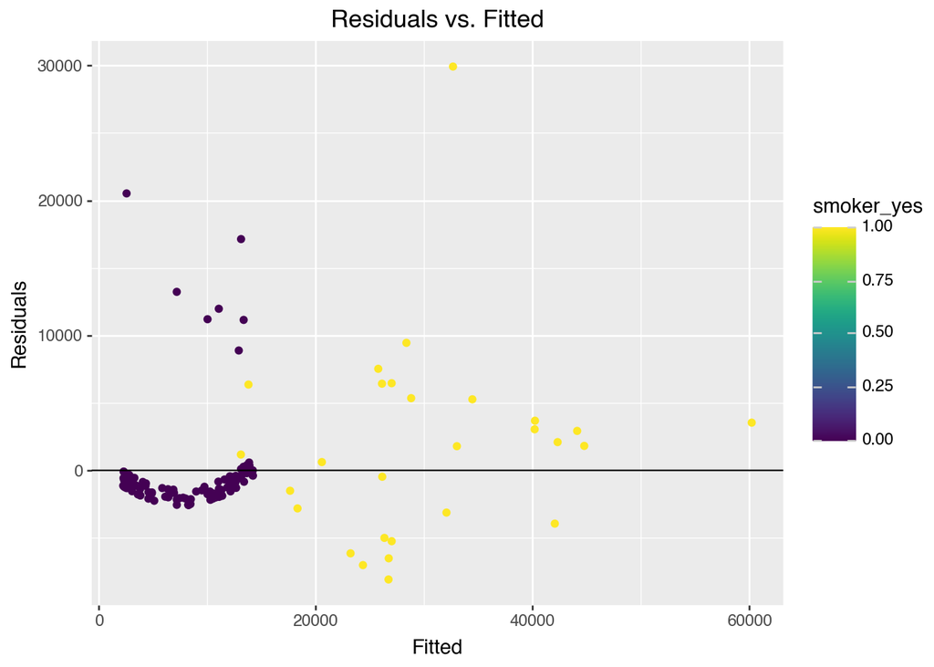

```python
import plotnine
from plotnine import *

y_predict = agebmismoker_model.predict(df_2[['age', 'bmi', 'smoker_yes', 'age_smoker', 'bmi_smoker']])

df_2["fitted"] = y_predict
df_2["residual"] = df_2["charges"] - y_predict

(
    ggplot(df_2, aes(x='y_predict', y='residual', color='smoker_yes'))
+ geom_point()
+ geom_hline(yintercept=0)
+ labs(title = 'Residuals vs. Fitted', x='Fitted', y='Residuals'))
```

Part Five: Full Exploration Using any variables in this dataset, and any polynomial of those variables, find the model that best predicts on the new data after being fit on the original data. (age + bmi + age^2)*smoker

```python
from sklearn.linear_model import LinearRegression
from sklearn.metrics import mean_squared_error
from plotnine import *

# convert smoker_yes to numeric
df["smoker_yes"] = df["smoker_yes"].astype(int)
df_2["smoker_yes"] = df_2["smoker_yes"].astype(int)

# add polynomial and interaction terms
df["age_square"] = df["age"] ** 2
df["age_smoker"] = df["age"] * df["smoker_yes"]
df["bmi_smoker"] = df["bmi"] * df["smoker_yes"]
df["age_square_smoker"] = df["age_square"] * df["smoker_yes"]

# same for df_2
df_2["age_square"] = df_2["age"] ** 2
df_2["age_smoker"] = df_2["age"] * df_2["smoker_yes"]
df_2["bmi_smoker"] = df_2["bmi"] * df_2["smoker_yes"]
df_2["age_square_smoker"] = df_2["age_square"] * df_2["smoker_yes"]

# train data
X_train = df[["age", "bmi", "age_square", "smoker_yes",
            "age_smoker", "bmi_smoker", "age_square_smoker"]]
y_train = df["charges"]

# train the model
final_model = LinearRegression()
final_model.fit(X=X_train, y=y_train)

# predict
y_predict = final_model.predict(df_2[["age", "bmi", "age_square", "smoker_yes",
            "age_smoker", "bmi_smoker", "age_square_smoker"]])

# calculate mse
mean_squared_error(df_2["charges"], y_predict)
```

```
21637148.258087184
```

MSE = 21637148.258087184

Plot the residuals

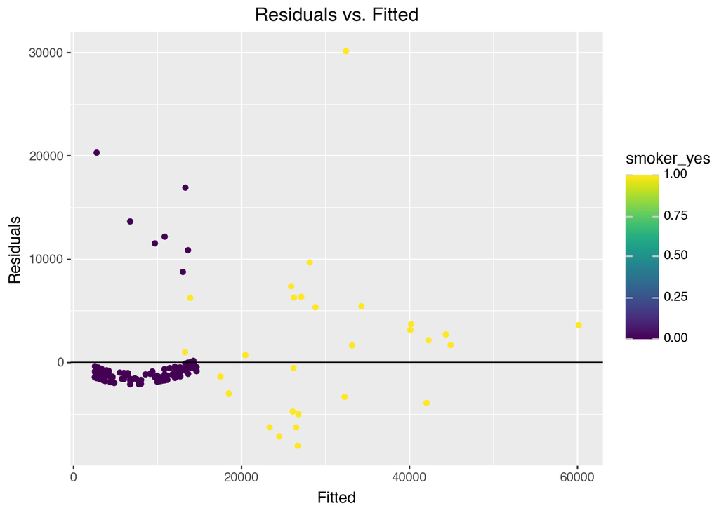

```python
df_2["fitted"] = y_predict
df_2["residual"] = df_2["charges"] - y_predict

(
    ggplot(df_2, aes(x='y_predict', y='residual', color='smoker_yes'))
    + geom_point()
    + geom_hline(yintercept=0)
    + labs(
        title='Residuals vs. Fitted',
        x='Fitted',
        y='Residuals'
    )
)
```

The residual plot shows the overall fit of the model for non-smokers. The main error is among smokers where charges vary and this suggests the model captures the general pattern of smokers paying much more but not all individual variability.